# Shopping Cart Data Analysis

#### 4.5.3 Model Evaluation

```python
from math import sqrt
from sklearn.metrics import mean_squared_error

rms = sqrt(mean_squared_error(test['total_sales'],y_pred_df['predictions'][0:5]))
print("RMSE: ", rms)
```

```
RMSE:  139.84765056705737
```

### 4.6 Sarima

#### 4.6.1 Splitting Data

```python
df_f = df_tm_p[:-1]

train = df_f[df_f['year_month'] <= pd.to_datetime('2021-06', format='%Y-%m')]
test = df_f[df_f['year_month'] >= pd.to_datetime('2021-06', format='%Y-%m')]

# plot
plt.figure(figsize=(10,5))
plt.plot( train['year_month'], train['total_sales'], color = "black", label="train")
plt.plot(test['year_month'], test['total_sales'], color = "red", label="test")
plt.title("Train/Test split for Sales Data")
plt.ylabel("Sales Number")
plt.xlabel('Month')
plt.xticks(rotation=45)
plt.legend()
plt.show()
```

[output not shown]

#### 4.6.2 Train Model

```python
month_predicted = [*range(5, 17, 1)]
```

[output not shown]

[output not shown]

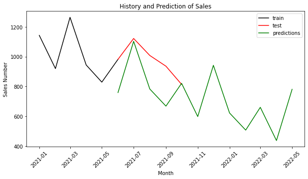

```python
from statsmodels.tsa.arima.model import ARIMA

y = train['total_sales']

SARIMAXmodel = SARIMAX(y, order = (2, 1, 2), seasonal_order=(2,1,2,5))
SARIMAXmodel = SARIMAXmodel.fit()

# prediction
y_pred = SARIMAXmodel.get_forecast(len(month_predicted))
y_pred_df = y_pred.conf_int(alpha = 0.05)
y_pred_df["predictions"] = SARIMAXmodel.predict(end = 17)
y_pred_df.index = month_predicted
y_pred_out = y_pred_df["predictions"]

# modif month
y_pred_df['year_month'] = test['year_month']
y_pred_df['year_month'][10] = pd.to_datetime('2021-11', format='%Y-%m')
y_pred_df['year_month'][11] = pd.to_datetime('2021-12', format='%Y-%m')
y_pred_df['year_month'][12] = pd.to_datetime('2022-01', format='%Y-%m')
y_pred_df['year_month'][13] = pd.to_datetime('2022-02', format='%Y-%m')
y_pred_df['year_month'][14] = pd.to_datetime('2022-03', format='%Y-%m')
y_pred_df['year_month'][15] = pd.to_datetime('2022-04', format='%Y-%m')
y_pred_df['year_month'][16] = pd.to_datetime('2022-05', format='%Y-%m')

# plot
plt.figure(figsize=(10,5))
plt.plot( train['year_month'], train['total_sales'], color = "black", label="train")
plt.plot(test['year_month'], test['total_sales'], color = "red", label="test")
plt.plot(y_pred_df['year_month'], y_pred_df['predictions'], color='green', label = 'predictions')
plt.title("History and Prediction of Sales")
plt.ylabel("Sales Number")
plt.xlabel('Month')
plt.xticks(rotation=45)
plt.legend()
plt.show()
```

#### 4.6.3 Model Evaluation

```python
from math import sqrt
from sklearn.metrics import mean_squared_error

rms = sqrt(mean_squared_error(test['total_sales'],y_pred_df['predictions'][0:5]))
print("RMSE: ", rms)
```

```
RMSE:  185.78912777662742
```

### 4.7 Sales Prediction

#### 4.7.1 Data Preprocessing

##### a. Feature Engineering

```python
df_prep = df.copy()
```

```python
df_prep['month'] = df_prep['order_date'].dt.month
df_prep['week'] = df_prep['order_date'].dt.week
df_prep['day'] = df_prep['order_date'].dt.day
df_prep['order_date'] = df_prep['order_date'].dt.date
```

```python
# daily sales

df_prep = df_prep.groupby(['order_date','month','week','day','season','product_type'], as_index=False)['quantity'].sum()

# pivot
df_prep_p = (
    df_prep
    .pivot_table(columns='product_type',index=['order_date','month','week','day','season'],aggfunc=np.sum,margins=True)['quantity']
)

# Formatting.
df_prep_p.reset_index(inplace=True)
df_prep_p.columns.name = None

df_prep_p.columns = ['order_date','month','week','day','season','jacket','shirt','trousers','total_sales']
df_prep_p = df_prep_p[:-1]
df_prep_p
```

|  | order_date | month | week | day | season | jacket | shirt | trousers | total_sales |
| --- | --- | --- | --- | --- | --- | --- | --- | --- | --- |
| 0 | 2021-01-01 | 1 | 53 | 1 | Summer | 4.0 | 13.0 | 14.0 | 31 |
| 1 | 2021-01-02 | 1 | 53 | 2 | Summer | 12.0 | 21.0 | 19.0 | 52 |
| 2 | 2021-01-03 | 1 | 53 | 3 | Summer | 11.0 | 2.0 | 12.0 | 25 |
| 3 | 2021-01-04 | 1 | 1 | 4 | Summer | 6.0 | 20.0 | 15.0 | 41 |
| 4 | 2021-01-05 | 1 | 1 | 5 | Summer | 25.0 | 11.0 | 20.0 | 56 |
| ... | ... | ... | ... | ... | ... | ... | ... | ... | ... |
| 286 | 2021-10-20 | 10 | 42 | 20 | Spring | 10.0 | 8.0 | 7.0 | 25 |
| 287 | 2021-10-21 | 10 | 42 | 21 | Spring | 15.0 | 20.0 | 26.0 | 61 |
| 288 | 2021-10-22 | 10 | 42 | 22 | Spring | 14.0 | 17.0 | 14.0 | 45 |
| 289 | 2021-10-23 | 10 | 42 | 23 | Spring | 1.0 | 11.0 | 8.0 | 20 |
| 290 | 2021-10-24 | 10 | 42 | 24 | Spring | 5.0 | 18.0 | 16.0 | 39 |

291 rows × 9 columns

##### b. Standardisation

```python
df_pred = df_prep_p.copy()
```

```python
from sklearn.preprocessing import StandardScaler

std_columns = ['month','week','day']

for i in std_columns:
    df_pred[i] = StandardScaler().fit_transform(df_pred[i].values.reshape(len(df_pred),1))
```

```python
df_pred = df_pred[['month','week','day','total_sales']]
```

```python
df_pred
```

|  | month | week | day | total_sales |
| --- | --- | --- | --- | --- |
| 0 | -1.567358 | 2.499801 | -1.663504 | 31 |
| 1 | -1.567358 | 2.499801 | -1.547999 | 52 |
| 2 | -1.567358 | 2.499801 | -1.432495 | 25 |
| 3 | -1.567358 | -1.670760 | -1.316990 | 41 |
| 4 | -1.567358 | -1.670760 | -1.201486 | 56 |
| ... | ... | ... | ... | ... |
| 286 | 1.622160 | 1.617567 | 0.531083 | 25 |
| 287 | 1.622160 | 1.617567 | 0.646587 | 61 |
| 288 | 1.622160 | 1.617567 | 0.762092 | 45 |
| 289 | 1.622160 | 1.617567 | 0.877597 | 20 |
| 290 | 1.622160 | 1.617567 | 0.993101 | 39 |

291 rows × 4 columns

#### 4.7.2 Model Evaluation

```python
df_pred.shape
```

```
(291, 4)
```

```python
# separate features and target
X = df_pred.drop(columns=['total_sales'], axis=1)
y = df_pred['total_sales']
```

```python
# Split into training and testing

from sklearn.model_selection import train_test_split

X_train, X_test, y_train, y_test = train_test_split(X, y, test_size = 0.2, random_state = 42)
m = len(X)
m_train = len(X_train)
m_test = len(X_test)

print("Total Data = " + str(m))
print("Train Data = " + str(m_train))
print("Test Data = " + str(m_test))
```

```
Total Data = 291
Train Data = 232
Test Data = 59
```

##### a. Linear Regression

```python
#Fitting simple linear regression to the Training Set
from sklearn.linear_model import LinearRegression

regressor = LinearRegression()
regressor.fit(X_train, y_train)

# Prediction
pred = regressor.predict(X_test)
```

```python
from sklearn.metrics import mean_squared_error, mean_absolute_error, r2_score

def eval_regression(model, pred, xtrain, ytrain, xtest, ytest):
    print("MAE: %.2f" % mean_absolute_error(ytest, pred)) # The MAE
    print("RMSE: %.2f" % mean_squared_error(ytest, pred, squared=False)) # The RMSE
    print('R2 score: %.2f' % r2_score(ytest, pred)) # Explained variance score: 1 is perfect prediction
```

```python
# evaluation

eval_regression(regressor, pred, X_train, y_train, X_test,y_test)
```

```
MAE: 18.38
RMSE: 22.18
R2 score: -0.10
```

```python
df_prep_p['sales_prediction'] = regressor.predict(X)
df_prep_p
```

|  | order_date | month | week | day | season | jacket | shirt | trousers | total_sales | sales_prediction |
| --- | --- | --- | --- | --- | --- | --- | --- | --- | --- | --- |
| 0 | 2021-01-01 | 1 | 53 | 1 | Summer | 4.0 | 13.0 | 14.0 | 31 | 35.398683 |
| 1 | 2021-01-02 | 1 | 53 | 2 | Summer | 12.0 | 21.0 | 19.0 | 52 | 35.628060 |
| 2 | 2021-01-03 | 1 | 53 | 3 | Summer | 11.0 | 2.0 | 12.0 | 25 | 35.857437 |
| 3 | 2021-01-04 | 1 | 1 | 4 | Summer | 6.0 | 20.0 | 15.0 | 41 | 34.184114 |
| 4 | 2021-01-05 | 1 | 1 | 5 | Summer | 25.0 | 11.0 | 20.0 | 56 | 34.413491 |
| ... | ... | ... | ... | ... | ... | ... | ... | ... | ... | ... |
| 286 | 2021-10-20 | 10 | 42 | 20 | Spring | 10.0 | 8.0 | 7.0 | 25 | 31.457654 |
| 287 | 2021-10-21 | 10 | 42 | 21 | Spring | 15.0 | 20.0 | 26.0 | 61 | 31.687032 |
| 288 | 2021-10-22 | 10 | 42 | 22 | Spring | 14.0 | 17.0 | 14.0 | 45 | 31.916409 |
| 289 | 2021-10-23 | 10 | 42 | 23 | Spring | 1.0 | 11.0 | 8.0 | 20 | 32.145786 |
| 290 | 2021-10-24 | 10 | 42 | 24 | Spring | 5.0 | 18.0 | 16.0 | 39 | 32.375163 |

291 rows × 10 columns

```python
# monthly
df_ml = df_prep_p.groupby(['month'], as_index=False)['total_sales'].sum()
df_ml_pred = df_prep_p.groupby(['month'], as_index=False)['sales_prediction'].sum()
```

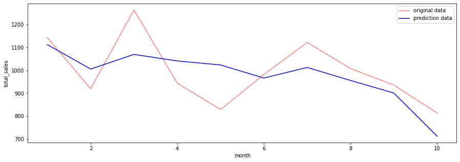

```python
fig = plt.figure(figsize=(15,5))

ax = fig.add_subplot(1, 1, 1)

sns.lineplot(data=df_ml, x='month',y='total_sales',ax=ax, color='red',alpha=0.5, label='original data')
sns.lineplot(data=df_ml_pred, x='month',y='sales_prediction',ax=ax, color='blue', label='prediction data')

plt.show()
```

*sales forecast in november and december*

```python
# november and december
df_pred_sales = pd.DataFrame(pd.date_range(start="2021-01-01",end="2021-12-31"), columns=['order_date'])

from_ts = pd.to_datetime('2021-10-24')
to_ts = pd.to_datetime('2021-10-31')
df_pred_sales = df_pred_sales[~((df_pred_sales.order_date > from_ts) & (df_pred_sales.order_date <= to_ts))]
```

```python
df_pred_sales
```

|  | order_date |
| --- | --- |
| 0 | 2021-01-01 |
| 1 | 2021-01-02 |
| 2 | 2021-01-03 |
| 3 | 2021-01-04 |
| 4 | 2021-01-05 |
| ... | ... |
| 360 | 2021-12-27 |
| 361 | 2021-12-28 |
| 362 | 2021-12-29 |
| 363 | 2021-12-30 |
| 364 | 2021-12-31 |

358 rows × 1 columns

```python
df_pred_sales['month'] = df_pred_sales['order_date'].dt.month
df_pred_sales['week'] = df_pred_sales['order_date'].dt.week
df_pred_sales['day'] = df_pred_sales['order_date'].dt.day
# df_pred_sales['order_date'] = df_pred_sales['order_date'].dt.date
df_pred_sales
```

|  | order_date | month | week | day |
| --- | --- | --- | --- | --- |
| 0 | 2021-01-01 | 1 | 53 | 1 |
| 1 | 2021-01-02 | 1 | 53 | 2 |
| 2 | 2021-01-03 | 1 | 53 | 3 |
| 3 | 2021-01-04 | 1 | 1 | 4 |
| 4 | 2021-01-05 | 1 | 1 | 5 |
| ... | ... | ... | ... | ... |
| 360 | 2021-12-27 | 12 | 52 | 27 |
| 361 | 2021-12-28 | 12 | 52 | 28 |
| 362 | 2021-12-29 | 12 | 52 | 29 |
| 363 | 2021-12-30 | 12 | 52 | 30 |
| 364 | 2021-12-31 | 12 | 52 | 31 |

358 rows × 4 columns

```python
df_pred_sales_std = df_pred_sales.copy()
```

```python
std_columns = ['month','week','day']

for i in std_columns:
    df_pred_sales_std[i] = StandardScaler().fit_transform(df_pred_sales_std[i].values.reshape(len(df_pred_sales_std),1))
```

```python
df_pred_sales['sales_prediction'] = regressor.predict(df_pred_sales_std.drop(columns=['order_date'], axis=1))
df_pred_sales
```

|  | order_date | month | week | day | sales_prediction |
| --- | --- | --- | --- | --- | --- |
| 0 | 2021-01-01 | 1 | 53 | 1 | 35.110812 |
| 1 | 2021-01-02 | 1 | 53 | 2 | 35.338903 |
| 2 | 2021-01-03 | 1 | 53 | 3 | 35.566994 |
| 3 | 2021-01-04 | 1 | 1 | 4 | 34.216653 |
| 4 | 2021-01-05 | 1 | 1 | 5 | 34.444744 |
| ... | ... | ... | ... | ... | ... |
| 360 | 2021-12-27 | 12 | 52 | 27 | 33.109254 |
| 361 | 2021-12-28 | 12 | 52 | 28 | 33.337346 |
| 362 | 2021-12-29 | 12 | 52 | 29 | 33.565437 |
| 363 | 2021-12-30 | 12 | 52 | 30 | 33.793528 |
| 364 | 2021-12-31 | 12 | 52 | 31 | 34.021619 |

358 rows × 5 columns

```python
# monthly
df_ml_pred_nov = df_pred_sales.groupby(['month'], as_index=False)['sales_prediction'].sum()
```

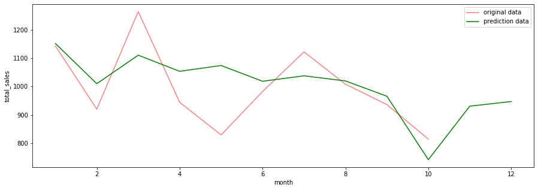

```python
fig = plt.figure(figsize=(15,5))

ax = fig.add_subplot(1, 1, 1)

sns.lineplot(data=df_ml, x='month',y='total_sales',ax=ax, color='red',alpha=0.5, label='original data')
sns.lineplot(data=df_ml_pred_nov, x='month',y='sales_prediction',ax=ax, color='green', label='prediction data')

plt.legend()
plt.show()
```

### 4.8 Jacket Sales Prediction

#### 4.8.1 Data Preprocessing

##### a. Feature Engineering

```python
df_prep_jacket = df.copy()
```

```python
df_prep_jacket['month'] = df_prep_jacket['order_date'].dt.month
df_prep_jacket['week'] = df_prep_jacket['order_date'].dt.week
df_prep_jacket['day'] = df_prep_jacket['order_date'].dt.day
df_prep_jacket['order_date'] = df_prep_jacket['order_date'].dt.date
```

```python
# daily sales

df_prep_jacket = df_prep_jacket.groupby(['order_date','month','week','day','season','product_type'], as_index=False)['quantity'].sum()

# pivot
df_prep_jacket_p = (
    df_prep_jacket
    .pivot_table(columns='product_type',index=['order_date','month','week','day','season'],aggfunc=np.sum,margins=True)['quantity']
)

# Formatting.
df_prep_jacket_p.reset_index(inplace=True)
df_prep_jacket_p.columns.name = None

df_prep_jacket_p.columns = ['order_date','month','week','day','season','jacket','shirt','trousers','total_sales']
df_prep_jacket_p = df_prep_jacket_p[:-1]
df_prep_jacket_p
```

|  | order_date | month | week | day | season | jacket | shirt | trousers | total_sales |
| --- | --- | --- | --- | --- | --- | --- | --- | --- | --- |
| 0 | 2021-01-01 | 1 | 53 | 1 | Summer | 4.0 | 13.0 | 14.0 | 31 |
| 1 | 2021-01-02 | 1 | 53 | 2 | Summer | 12.0 | 21.0 | 19.0 | 52 |
| 2 | 2021-01-03 | 1 | 53 | 3 | Summer | 11.0 | 2.0 | 12.0 | 25 |
| 3 | 2021-01-04 | 1 | 1 | 4 | Summer | 6.0 | 20.0 | 15.0 | 41 |
| 4 | 2021-01-05 | 1 | 1 | 5 | Summer | 25.0 | 11.0 | 20.0 | 56 |
| ... | ... | ... | ... | ... | ... | ... | ... | ... | ... |
| 286 | 2021-10-20 | 10 | 42 | 20 | Spring | 10.0 | 8.0 | 7.0 | 25 |
| 287 | 2021-10-21 | 10 | 42 | 21 | Spring | 15.0 | 20.0 | 26.0 | 61 |
| 288 | 2021-10-22 | 10 | 42 | 22 | Spring | 14.0 | 17.0 | 14.0 | 45 |
| 289 | 2021-10-23 | 10 | 42 | 23 | Spring | 1.0 | 11.0 | 8.0 | 20 |
| 290 | 2021-10-24 | 10 | 42 | 24 | Spring | 5.0 | 18.0 | 16.0 | 39 |

291 rows × 9 columns

##### b. Standardisation

```python
df_pred_jacket = df_prep_jacket_p.copy()
```

```python
from sklearn.preprocessing import StandardScaler

std_columns = ['month','week','day']

for i in std_columns:
    df_pred_jacket[i] = StandardScaler().fit_transform(df_pred_jacket[i].values.reshape(len(df_pred_jacket),1))
```

```python
df_pred_jacket = df_pred_jacket[['month','week','day','jacket']]
```

```python
df_pred_jacket['jacket'].fillna(df_pred_jacket['jacket'].mean(), inplace=True)
```

#### 4.8.2 Model Evaluation

```python
df_pred_jacket.shape
```

```
(291, 4)
```

```python
# separate features and target
X = df_pred_jacket.drop(columns=['jacket'], axis=1)
y = df_pred_jacket['jacket']
```

```python
# Split into training and testing

from sklearn.model_selection import train_test_split

X_train, X_test, y_train, y_test = train_test_split(X, y, test_size = 0.2, random_state = 42)
m = len(X)
m_train = len(X_train)
m_test = len(X_test)

print("Total Data = " + str(m))
print("Train Data = " + str(m_train))
print("Test Data = " + str(m_test))
```

```
Total Data = 291
Train Data = 232
Test Data = 59
```

##### a. Linear Regression

```python
#Fitting simple linear regression to the Training Set
from sklearn.linear_model import LinearRegression

regressor = LinearRegression()
regressor.fit(X_train, y_train)

# Prediction
pred_jacket = regressor.predict(X_test)
```

```python
from sklearn.metrics import mean_squared_error, mean_absolute_error, r2_score

def eval_regression(model, pred, xtrain, ytrain, xtest, ytest):
    print("MAE: %.2f" % mean_absolute_error(ytest, pred_jacket)) # The MAE
    print("RMSE: %.2f" % mean_squared_error(ytest, pred_jacket, squared=False)) # The RMSE
    print('R2 score: %.2f' % r2_score(ytest, pred_jacket)) # Explained variance score: 1 is perfect prediction
```

```python
# evaluation

eval_regression(regressor, pred, X_train, y_train, X_test,y_test)
```

```
MAE: 7.14
RMSE: 9.22
R2 score: -0.07
```

```python
df_prep_jacket_p['jacket_prediction'] = regressor.predict(X)
df_prep_jacket_p
```

|  | order_date | month | week | day | season | jacket | shirt | trousers | total_sales | jacket_prediction |
| --- | --- | --- | --- | --- | --- | --- | --- | --- | --- | --- |
| 0 | 2021-01-01 | 1 | 53 | 1 | Summer | 4.0 | 13.0 | 14.0 | 31 | 8.854399 |
| 1 | 2021-01-02 | 1 | 53 | 2 | Summer | 12.0 | 21.0 | 19.0 | 52 | 8.958534 |
| 2 | 2021-01-03 | 1 | 53 | 3 | Summer | 11.0 | 2.0 | 12.0 | 25 | 9.062669 |
| 3 | 2021-01-04 | 1 | 1 | 4 | Summer | 6.0 | 20.0 | 15.0 | 41 | 11.807883 |
| 4 | 2021-01-05 | 1 | 1 | 5 | Summer | 25.0 | 11.0 | 20.0 | 56 | 11.912018 |
| ... | ... | ... | ... | ... | ... | ... | ... | ... | ... | ... |
| 286 | 2021-10-20 | 10 | 42 | 20 | Spring | 10.0 | 8.0 | 7.0 | 25 | 11.129182 |
| 287 | 2021-10-21 | 10 | 42 | 21 | Spring | 15.0 | 20.0 | 26.0 | 61 | 11.233317 |
| 288 | 2021-10-22 | 10 | 42 | 22 | Spring | 14.0 | 17.0 | 14.0 | 45 | 11.337452 |
| 289 | 2021-10-23 | 10 | 42 | 23 | Spring | 1.0 | 11.0 | 8.0 | 20 | 11.441587 |
| 290 | 2021-10-24 | 10 | 42 | 24 | Spring | 5.0 | 18.0 | 16.0 | 39 | 11.545722 |

291 rows × 10 columns

```python
# monthly
df_ml_jacket = df_prep_jacket_p.groupby(['month'], as_index=False)['jacket'].sum()
df_ml_jacket_pred = df_prep_jacket_p.groupby(['month'], as_index=False)['jacket_prediction'].sum()
```

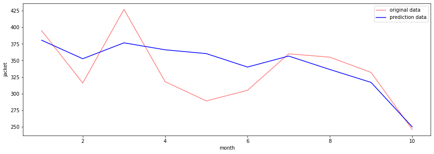

```python
fig = plt.figure(figsize=(15,5))

ax = fig.add_subplot(1, 1, 1)

sns.lineplot(data=df_ml_jacket, x='month',y='jacket',ax=ax, color='red',alpha=0.5, label='original data')
sns.lineplot(data=df_ml_jacket_pred, x='month',y='jacket_prediction',ax=ax, color='blue', label='prediction data')

plt.show()
```

*prediction of jacket sales in november and december*

```python
# november and december
df_pred_jacket_sales = pd.DataFrame(pd.date_range(start="2021-01-01",end="2021-12-31"), columns=['order_date'])

from_ts = pd.to_datetime('2021-10-24')
to_ts = pd.to_datetime('2021-10-31')
df_pred_jacket_sales = df_pred_jacket_sales[~((df_pred_jacket_sales.order_date > from_ts) & (df_pred_sales.order_date <= to_ts))]
```

```python
df_pred_jacket_sales
```

|  | order_date |
| --- | --- |
| 0 | 2021-01-01 |
| 1 | 2021-01-02 |
| 2 | 2021-01-03 |
| 3 | 2021-01-04 |
| 4 | 2021-01-05 |
| ... | ... |
| 360 | 2021-12-27 |
| 361 | 2021-12-28 |
| 362 | 2021-12-29 |
| 363 | 2021-12-30 |
| 364 | 2021-12-31 |

365 rows × 1 columns

```python
df_pred_jacket_sales['month'] = df_pred_jacket_sales['order_date'].dt.month
df_pred_jacket_sales['week'] = df_pred_jacket_sales['order_date'].dt.week
df_pred_jacket_sales['day'] = df_pred_jacket_sales['order_date'].dt.day
# df_pred_jacket_sales['order_date'] = df_pred_jacket_sales['order_date'].dt.date
df_pred_jacket_sales
```

|  | order_date | month | week | day |
| --- | --- | --- | --- | --- |
| 0 | 2021-01-01 | 1 | 53 | 1 |
| 1 | 2021-01-02 | 1 | 53 | 2 |
| 2 | 2021-01-03 | 1 | 53 | 3 |
| 3 | 2021-01-04 | 1 | 1 | 4 |
| 4 | 2021-01-05 | 1 | 1 | 5 |
| ... | ... | ... | ... | ... |
| 360 | 2021-12-27 | 12 | 52 | 27 |
| 361 | 2021-12-28 | 12 | 52 | 28 |
| 362 | 2021-12-29 | 12 | 52 | 29 |
| 363 | 2021-12-30 | 12 | 52 | 30 |
| 364 | 2021-12-31 | 12 | 52 | 31 |

365 rows × 4 columns

```python
df_pred_jacket_sales_std = df_pred_jacket_sales.copy()
```

```python
std_columns = ['month','week','day']

for i in std_columns:
    df_pred_jacket_sales_std[i] = StandardScaler().fit_transform(df_pred_jacket_sales_std[i].values.reshape(len(df_pred_jacket_sales_std),1))
```

```python
df_pred_jacket_sales['jacket_prediction'] = regressor.predict(df_pred_jacket_sales_std.drop(columns=['order_date'], axis=1))
df_pred_jacket_sales
```

|  | order_date | month | week | day | jacket_prediction |
| --- | --- | --- | --- | --- | --- |
| 0 | 2021-01-01 | 1 | 53 | 1 | 9.320385 |
| 1 | 2021-01-02 | 1 | 53 | 2 | 9.422879 |
| 2 | 2021-01-03 | 1 | 53 | 3 | 9.525374 |
| 3 | 2021-01-04 | 1 | 1 | 4 | 11.814293 |
| 4 | 2021-01-05 | 1 | 1 | 5 | 11.916787 |
| ... | ... | ... | ... | ... | ... |
| 360 | 2021-12-27 | 12 | 52 | 27 | 11.764742 |
| 361 | 2021-12-28 | 12 | 52 | 28 | 11.867237 |
| 362 | 2021-12-29 | 12 | 52 | 29 | 11.969731 |
| 363 | 2021-12-30 | 12 | 52 | 30 | 12.072225 |
| 364 | 2021-12-31 | 12 | 52 | 31 | 12.174720 |

365 rows × 5 columns

```python
# monthly
df_ml_jacket_pred_nov = df_pred_jacket_sales.groupby(['month'], as_index=False)['jacket_prediction'].sum()
```

### 4.9 Trousers Sales Prediction

#### 4.9.1 Data Preprocessing

##### a. Feature Engineering

```python
df_prep_trousers = df.copy()
```

```python
df_prep_trousers['month'] = df_prep_trousers['order_date'].dt.month
df_prep_trousers['week'] = df_prep_trousers['order_date'].dt.week
df_prep_trousers['day'] = df_prep_trousers['order_date'].dt.day
df_prep_trousers['order_date'] = df_prep_trousers['order_date'].dt.date
```

```python
# daily sales

df_prep_trousers = df_prep_trousers.groupby(['order_date','month','week','day','season','product_type'], as_index=False)['quantity'].sum()

# pivot
df_prep_trousers_p = (
    df_prep_trousers
    .pivot_table(columns='product_type',index=['order_date','month','week','day','season'],aggfunc=np.sum,margins=True)['quantity']
)

# Formatting.
df_prep_trousers_p.reset_index(inplace=True)
df_prep_trousers_p.columns.name = None

df_prep_trousers_p.columns = ['order_date','month','week','day','season','jacket','shirt','trousers','total_sales']
df_prep_trousers_p = df_prep_trousers_p[:-1]
df_prep_trousers_p
```

|  | order_date | month | week | day | season | jacket | shirt | trousers | total_sales |
| --- | --- | --- | --- | --- | --- | --- | --- | --- | --- |
| 0 | 2021-01-01 | 1 | 53 | 1 | Summer | 4.0 | 13.0 | 14.0 | 31 |
| 1 | 2021-01-02 | 1 | 53 | 2 | Summer | 12.0 | 21.0 | 19.0 | 52 |
| 2 | 2021-01-03 | 1 | 53 | 3 | Summer | 11.0 | 2.0 | 12.0 | 25 |
| 3 | 2021-01-04 | 1 | 1 | 4 | Summer | 6.0 | 20.0 | 15.0 | 41 |
| 4 | 2021-01-05 | 1 | 1 | 5 | Summer | 25.0 | 11.0 | 20.0 | 56 |
| ... | ... | ... | ... | ... | ... | ... | ... | ... | ... |
| 286 | 2021-10-20 | 10 | 42 | 20 | Spring | 10.0 | 8.0 | 7.0 | 25 |
| 287 | 2021-10-21 | 10 | 42 | 21 | Spring | 15.0 | 20.0 | 26.0 | 61 |
| 288 | 2021-10-22 | 10 | 42 | 22 | Spring | 14.0 | 17.0 | 14.0 | 45 |
| 289 | 2021-10-23 | 10 | 42 | 23 | Spring | 1.0 | 11.0 | 8.0 | 20 |
| 290 | 2021-10-24 | 10 | 42 | 24 | Spring | 5.0 | 18.0 | 16.0 | 39 |

291 rows × 9 columns

##### b. Standardisation

```python
df_pred_trousers = df_prep_trousers_p.copy()
```

```python
from sklearn.preprocessing import StandardScaler

std_columns = ['month','week','day']

for i in std_columns:
    df_pred_trousers[i] = StandardScaler().fit_transform(df_pred_trousers[i].values.reshape(len(df_pred_trousers),1))
```

```python
df_pred_trousers = df_pred_trousers[['month','week','day','trousers']]
```

```python
df_pred_trousers
```

|  | month | week | day | trousers |
| --- | --- | --- | --- | --- |
| 0 | -1.567358 | 2.499801 | -1.663504 | 14.0 |
| 1 | -1.567358 | 2.499801 | -1.547999 | 19.0 |
| 2 | -1.567358 | 2.499801 | -1.432495 | 12.0 |
| 3 | -1.567358 | -1.670760 | -1.316990 | 15.0 |
| 4 | -1.567358 | -1.670760 | -1.201486 | 20.0 |
| ... | ... | ... | ... | ... |
| 286 | 1.622160 | 1.617567 | 0.531083 | 7.0 |
| 287 | 1.622160 | 1.617567 | 0.646587 | 26.0 |
| 288 | 1.622160 | 1.617567 | 0.762092 | 14.0 |
| 289 | 1.622160 | 1.617567 | 0.877597 | 8.0 |
| 290 | 1.622160 | 1.617567 | 0.993101 | 16.0 |

291 rows × 4 columns

```python
df_pred_trousers['trousers'].fillna(df_pred_trousers['trousers'].mean(), inplace=True)
```

#### 4.9.2 Model Evaluation

```python
df_pred_trousers.shape
```

```
(291, 4)
```

```python
# separate features and target
X = df_pred_trousers.drop(columns=['trousers'], axis=1)
y = df_pred_trousers['trousers']
```

```python
# Split into training and testing

from sklearn.model_selection import train_test_split

X_train, X_test, y_train, y_test = train_test_split(X, y, test_size = 0.2, random_state = 42)
m = len(X)
m_train = len(X_train)
m_test = len(X_test)

print("Total Data = " + str(m))
print("Train Data = " + str(m_train))
print("Test Data = " + str(m_test))
```

```
Total Data = 291
Train Data = 232
Test Data = 59
```

##### a. Linear Regression

```python
#Fitting simple linear regression to the Training Set
from sklearn.linear_model import LinearRegression

regressor = LinearRegression()
regressor.fit(X_train, y_train)

# Prediction
pred_trousers = regressor.predict(X_test)
```

```python
from sklearn.metrics import mean_squared_error, mean_absolute_error, r2_score

def eval_regression(model, pred, xtrain, ytrain, xtest, ytest):
    print("MAE: %.2f" % mean_absolute_error(ytest, pred_trousers)) # The MAE
    print("RMSE: %.2f" % mean_squared_error(ytest, pred_trousers, squared=False)) # The RMSE
    print('R2 score: %.2f' % r2_score(ytest, pred_trousers)) # Explained variance score: 1 is perfect prediction
```

```python
# evaluation

eval_regression(regressor, pred, X_train, y_train, X_test,y_test)
```

```
MAE: 5.97
RMSE: 7.47
R2 score: -0.08
```

```python
df_prep_trousers_p['trousers_prediction'] = regressor.predict(X)
df_prep_trousers_p
```

|  | order_date | month | week | day | season | jacket | shirt | trousers | total_sales | trousers_prediction |
| --- | --- | --- | --- | --- | --- | --- | --- | --- | --- | --- |
| 0 | 2021-01-01 | 1 | 53 | 1 | Summer | 4.0 | 13.0 | 14.0 | 31 | 14.739787 |
| 1 | 2021-01-02 | 1 | 53 | 2 | Summer | 12.0 | 21.0 | 19.0 | 52 | 14.842097 |
| 2 | 2021-01-03 | 1 | 53 | 3 | Summer | 11.0 | 2.0 | 12.0 | 25 | 14.944406 |
| 3 | 2021-01-04 | 1 | 1 | 4 | Summer | 6.0 | 20.0 | 15.0 | 41 | 11.562323 |
| 4 | 2021-01-05 | 1 | 1 | 5 | Summer | 25.0 | 11.0 | 20.0 | 56 | 11.664633 |
| ... | ... | ... | ... | ... | ... | ... | ... | ... | ... | ... |
| 286 | 2021-10-20 | 10 | 42 | 20 | Spring | 10.0 | 8.0 | 7.0 | 25 | 11.732799 |
| 287 | 2021-10-21 | 10 | 42 | 21 | Spring | 15.0 | 20.0 | 26.0 | 61 | 11.835109 |
| 288 | 2021-10-22 | 10 | 42 | 22 | Spring | 14.0 | 17.0 | 14.0 | 45 | 11.937418 |
| 289 | 2021-10-23 | 10 | 42 | 23 | Spring | 1.0 | 11.0 | 8.0 | 20 | 12.039728 |
| 290 | 2021-10-24 | 10 | 42 | 24 | Spring | 5.0 | 18.0 | 16.0 | 39 | 12.142037 |

291 rows × 10 columns

```python
# monthly
df_ml_trousers = df_prep_trousers_p.groupby(['month'], as_index=False)['trousers'].sum()
df_ml_trousers_pred = df_prep_trousers_p.groupby(['month'], as_index=False)['trousers_prediction'].sum()
```

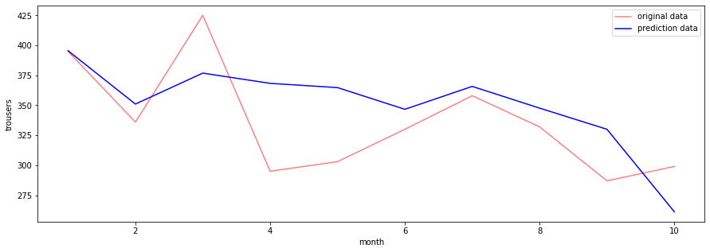

```python
fig = plt.figure(figsize=(15,5))

ax = fig.add_subplot(1, 1, 1)

sns.lineplot(data=df_ml_trousers, x='month',y='trousers',ax=ax, color='red',alpha=0.5, label='original data')
sns.lineplot(data=df_ml_trousers_pred, x='month',y='trousers_prediction',ax=ax, color='blue', label='prediction data')

plt.show()
```

*prediction of trousers sales in november and december*

```python
# november and december
df_pred_trousers_sales = pd.DataFrame(pd.date_range(start="2021-01-01",end="2021-12-31"), columns=['order_date'])

from_ts = pd.to_datetime('2021-10-24')
to_ts = pd.to_datetime('2021-10-31')
df_pred_trousers_sales = df_pred_trousers_sales[~((df_pred_trousers_sales.order_date > from_ts) & (df_pred_sales.order_date <= to_ts))]
```

```python
df_pred_trousers_sales
```

|  | order_date |
| --- | --- |
| 0 | 2021-01-01 |
| 1 | 2021-01-02 |
| 2 | 2021-01-03 |
| 3 | 2021-01-04 |
| 4 | 2021-01-05 |
| ... | ... |
| 360 | 2021-12-27 |
| 361 | 2021-12-28 |
| 362 | 2021-12-29 |
| 363 | 2021-12-30 |
| 364 | 2021-12-31 |

365 rows × 1 columns

```python
df_pred_trousers_sales['month'] = df_pred_trousers_sales['order_date'].dt.month
df_pred_trousers_sales['week'] = df_pred_trousers_sales['order_date'].dt.week
df_pred_trousers_sales['day'] = df_pred_trousers_sales['order_date'].dt.day
# df_pred_trousers_sales['order_date'] = df_pred_trousers_sales['order_date'].dt.date
df_pred_trousers_sales
```

|  | order_date | month | week | day |
| --- | --- | --- | --- | --- |
| 0 | 2021-01-01 | 1 | 53 | 1 |
| 1 | 2021-01-02 | 1 | 53 | 2 |
| 2 | 2021-01-03 | 1 | 53 | 3 |
| 3 | 2021-01-04 | 1 | 1 | 4 |
| 4 | 2021-01-05 | 1 | 1 | 5 |
| ... | ... | ... | ... | ... |
| 360 | 2021-12-27 | 12 | 52 | 27 |
| 361 | 2021-12-28 | 12 | 52 | 28 |
| 362 | 2021-12-29 | 12 | 52 | 29 |
| 363 | 2021-12-30 | 12 | 52 | 30 |
| 364 | 2021-12-31 | 12 | 52 | 31 |

365 rows × 4 columns

```python
df_pred_trousers_sales_std = df_pred_trousers_sales.copy()
```

```python
std_columns = ['month','week','day']

for i in std_columns:
    df_pred_trousers_sales_std[i] = StandardScaler().fit_transform(df_pred_trousers_sales_std[i].values.reshape(len(df_pred_trousers_sales_std),1))
```

```python
df_pred_trousers_sales['trousers_prediction'] = regressor.predict(df_pred_trousers_sales_std.drop(columns=['order_date'], axis=1))
df_pred_trousers_sales
```

|  | order_date | month | week | day | trousers_prediction |
| --- | --- | --- | --- | --- | --- |
| 0 | 2021-01-01 | 1 | 53 | 1 | 14.154852 |
| 1 | 2021-01-02 | 1 | 53 | 2 | 14.255550 |
| 2 | 2021-01-03 | 1 | 53 | 3 | 14.356247 |
| 3 | 2021-01-04 | 1 | 1 | 4 | 11.572381 |
| 4 | 2021-01-05 | 1 | 1 | 5 | 11.673079 |
| ... | ... | ... | ... | ... | ... |
| 360 | 2021-12-27 | 12 | 52 | 27 | 12.502577 |
| 361 | 2021-12-28 | 12 | 52 | 28 | 12.603275 |
| 362 | 2021-12-29 | 12 | 52 | 29 | 12.703972 |
| 363 | 2021-12-30 | 12 | 52 | 30 | 12.804670 |
| 364 | 2021-12-31 | 12 | 52 | 31 | 12.905368 |

365 rows × 5 columns

```python
# monthly
df_ml_trousers_pred_nov = df_pred_trousers_sales.groupby(['month'], as_index=False)['trousers_prediction'].sum()
```

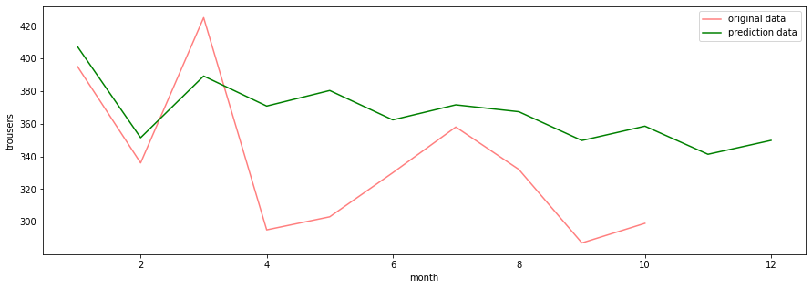

```python
fig = plt.figure(figsize=(15,5))

ax = fig.add_subplot(1, 1, 1)

sns.lineplot(data=df_ml_trousers, x='month',y='trousers',ax=ax, color='red',alpha=0.5, label='original data')
sns.lineplot(data=df_ml_trousers_pred_nov, x='month',y='trousers_prediction',ax=ax, color='green', label='prediction data')

plt.legend()
plt.show()
```

### 4.10 Shirt Sales Prediction

#### 4.10.1 Data Preprocessing

##### a. Feature Engineering

```python
df_prep_shirt = df.copy()
```

```python
df_prep_shirt['month'] = df_prep_shirt['order_date'].dt.month
df_prep_shirt['week'] = df_prep_shirt['order_date'].dt.week
df_prep_shirt['day'] = df_prep_shirt['order_date'].dt.day
df_prep_shirt['order_date'] = df_prep_shirt['order_date'].dt.date
```

```python
# daily sales

df_prep_shirt = df_prep_shirt.groupby(['order_date','month','week','day','season','product_type'], as_index=False)['quantity'].sum()

# pivot
df_prep_shirt_p = (
    df_prep_shirt
    .pivot_table(columns='product_type',index=['order_date','month','week','day','season'],aggfunc=np.sum,margins=True)['quantity']
)

# Formatting.
df_prep_shirt_p.reset_index(inplace=True)
df_prep_shirt_p.columns.name = None

df_prep_shirt_p.columns = ['order_date','month','week','day','season','jacket','shirt','trousers','total_sales']
df_prep_shirt_p = df_prep_shirt_p[:-1]
df_prep_shirt_p
```

|  | order_date | month | week | day | season | jacket | shirt | trousers | total_sales |
| --- | --- | --- | --- | --- | --- | --- | --- | --- | --- |
| 0 | 2021-01-01 | 1 | 53 | 1 | Summer | 4.0 | 13.0 | 14.0 | 31 |
| 1 | 2021-01-02 | 1 | 53 | 2 | Summer | 12.0 | 21.0 | 19.0 | 52 |
| 2 | 2021-01-03 | 1 | 53 | 3 | Summer | 11.0 | 2.0 | 12.0 | 25 |
| 3 | 2021-01-04 | 1 | 1 | 4 | Summer | 6.0 | 20.0 | 15.0 | 41 |
| 4 | 2021-01-05 | 1 | 1 | 5 | Summer | 25.0 | 11.0 | 20.0 | 56 |
| ... | ... | ... | ... | ... | ... | ... | ... | ... | ... |
| 286 | 2021-10-20 | 10 | 42 | 20 | Spring | 10.0 | 8.0 | 7.0 | 25 |
| 287 | 2021-10-21 | 10 | 42 | 21 | Spring | 15.0 | 20.0 | 26.0 | 61 |
| 288 | 2021-10-22 | 10 | 42 | 22 | Spring | 14.0 | 17.0 | 14.0 | 45 |
| 289 | 2021-10-23 | 10 | 42 | 23 | Spring | 1.0 | 11.0 | 8.0 | 20 |
| 290 | 2021-10-24 | 10 | 42 | 24 | Spring | 5.0 | 18.0 | 16.0 | 39 |

291 rows × 9 columns

##### b. Standardisation

```python
df_pred_shirt = df_prep_shirt_p.copy()
```

```python
from sklearn.preprocessing import StandardScaler

std_columns = ['month','week','day']

for i in std_columns:
    df_pred_shirt[i] = StandardScaler().fit_transform(df_pred_shirt[i].values.reshape(len(df_pred_shirt),1))
```

```python
df_pred_shirt = df_pred_shirt[['month','week','day','shirt']]
```

```python
df_pred_shirt
```

|  | month | week | day | shirt |
| --- | --- | --- | --- | --- |
| 0 | -1.567358 | 2.499801 | -1.663504 | 13.0 |
| 1 | -1.567358 | 2.499801 | -1.547999 | 21.0 |
| 2 | -1.567358 | 2.499801 | -1.432495 | 2.0 |
| 3 | -1.567358 | -1.670760 | -1.316990 | 20.0 |
| 4 | -1.567358 | -1.670760 | -1.201486 | 11.0 |
| ... | ... | ... | ... | ... |
| 286 | 1.622160 | 1.617567 | 0.531083 | 8.0 |
| 287 | 1.622160 | 1.617567 | 0.646587 | 20.0 |
| 288 | 1.622160 | 1.617567 | 0.762092 | 17.0 |
| 289 | 1.622160 | 1.617567 | 0.877597 | 11.0 |
| 290 | 1.622160 | 1.617567 | 0.993101 | 18.0 |

291 rows × 4 columns

```python
df_pred_shirt['shirt'].fillna(df_pred_shirt['shirt'].mean(), inplace=True)
```

#### 4.10.2 Model Evaluation

```python
df_pred_shirt.shape
```

```
(291, 4)
```

```python
# separate features and target
X = df_pred_shirt.drop(columns=['shirt'], axis=1)
y = df_pred_shirt['shirt']
```

```python
# Split into training and testing

from sklearn.model_selection import train_test_split

X_train, X_test, y_train, y_test = train_test_split(X, y, test_size = 0.2, random_state = 42)
m = len(X)
m_train = len(X_train)
m_test = len(X_test)

print("Total Data = " + str(m))
print("Train Data = " + str(m_train))
print("Test Data = " + str(m_test))
```

```
Total Data = 291
Train Data = 232
Test Data = 59
```

##### a. Linear Regression

```python
#Fitting simple linear regression to the Training Set
from sklearn.linear_model import LinearRegression

regressor = LinearRegression()
regressor.fit(X_train, y_train)

# Prediction
pred_shirt = regressor.predict(X_test)
```

```python
from sklearn.metrics import mean_squared_error, mean_absolute_error, r2_score

def eval_regression(model, pred, xtrain, ytrain, xtest, ytest):
    print("MAE: %.2f" % mean_absolute_error(ytest, pred_shirt)) # The MAE
    print("RMSE: %.2f" % mean_squared_error(ytest, pred_shirt, squared=False)) # The RMSE
    print('R2 score: %.2f' % r2_score(ytest, pred_shirt)) # Explained variance score: 1 is perfect prediction
```

```python
# evaluation

eval_regression(regressor, pred, X_train, y_train, X_test,y_test)
```

```
MAE: 6.09
RMSE: 8.20
R2 score: -0.13
```

```python
df_prep_shirt_p['shirt_prediction'] = regressor.predict(X)
df_prep_shirt_p
```

|  | order_date | month | week | day | season | jacket | shirt | trousers | total_sales | shirt_prediction |
| --- | --- | --- | --- | --- | --- | --- | --- | --- | --- | --- |
| 0 | 2021-01-01 | 1 | 53 | 1 | Summer | 4.0 | 13.0 | 14.0 | 31 | 11.879875 |
| 1 | 2021-01-02 | 1 | 53 | 2 | Summer | 12.0 | 21.0 | 19.0 | 52 | 11.963034 |
| 2 | 2021-01-03 | 1 | 53 | 3 | Summer | 11.0 | 2.0 | 12.0 | 25 | 12.046194 |
| 3 | 2021-01-04 | 1 | 1 | 4 | Summer | 6.0 | 20.0 | 15.0 | 41 | 11.332987 |
| 4 | 2021-01-05 | 1 | 1 | 5 | Summer | 25.0 | 11.0 | 20.0 | 56 | 11.416146 |
| ... | ... | ... | ... | ... | ... | ... | ... | ... | ... | ... |
| 286 | 2021-10-20 | 10 | 42 | 20 | Spring | 10.0 | 8.0 | 7.0 | 25 | 10.663357 |
| 287 | 2021-10-21 | 10 | 42 | 21 | Spring | 15.0 | 20.0 | 26.0 | 61 | 10.746516 |
| 288 | 2021-10-22 | 10 | 42 | 22 | Spring | 14.0 | 17.0 | 14.0 | 45 | 10.829675 |
| 289 | 2021-10-23 | 10 | 42 | 23 | Spring | 1.0 | 11.0 | 8.0 | 20 | 10.912835 |
| 290 | 2021-10-24 | 10 | 42 | 24 | Spring | 5.0 | 18.0 | 16.0 | 39 | 10.995994 |

291 rows × 10 columns

```python
# monthly
df_ml_shirt = df_prep_shirt_p.groupby(['month'], as_index=False)['shirt'].sum()
df_ml_shirt_pred = df_prep_shirt_p.groupby(['month'], as_index=False)['shirt_prediction'].sum()
```

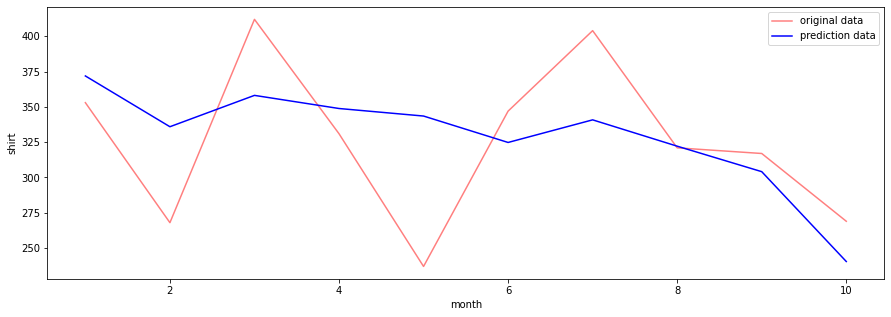

```python
fig = plt.figure(figsize=(15,5))

ax = fig.add_subplot(1, 1, 1)

sns.lineplot(data=df_ml_shirt, x='month',y='shirt',ax=ax, color='red',alpha=0.5, label='original data')
sns.lineplot(data=df_ml_shirt_pred, x='month',y='shirt_prediction',ax=ax, color='blue', label='prediction data')

plt.show()
```

*prediction of shirt sales in november and december*

```python
# november and december
df_pred_shirt_sales = pd.DataFrame(pd.date_range(start="2021-01-01",end="2021-12-31"), columns=['order_date'])

from_ts = pd.to_datetime('2021-10-24')
to_ts = pd.to_datetime('2021-10-31')
df_pred_shirt_sales = df_pred_shirt_sales[~((df_pred_shirt_sales.order_date > from_ts) & (df_pred_sales.order_date <= to_ts))]
```

```python
df_pred_shirt_sales
```

|  | order_date |
| --- | --- |
| 0 | 2021-01-01 |
| 1 | 2021-01-02 |
| 2 | 2021-01-03 |
| 3 | 2021-01-04 |
| 4 | 2021-01-05 |
| ... | ... |
| 360 | 2021-12-27 |
| 361 | 2021-12-28 |
| 362 | 2021-12-29 |
| 363 | 2021-12-30 |
| 364 | 2021-12-31 |

365 rows × 1 columns

```python
df_pred_shirt_sales['month'] = df_pred_shirt_sales['order_date'].dt.month
df_pred_shirt_sales['week'] = df_pred_shirt_sales['order_date'].dt.week
df_pred_shirt_sales['day'] = df_pred_shirt_sales['order_date'].dt.day
# df_pred_shirt_sales['order_date'] = df_pred_shirt_sales['order_date'].dt.date
df_pred_shirt_sales
```

|  | order_date | month | week | day |
| --- | --- | --- | --- | --- |
| 0 | 2021-01-01 | 1 | 53 | 1 |
| 1 | 2021-01-02 | 1 | 53 | 2 |
| 2 | 2021-01-03 | 1 | 53 | 3 |
| 3 | 2021-01-04 | 1 | 1 | 4 |
| 4 | 2021-01-05 | 1 | 1 | 5 |
| ... | ... | ... | ... | ... |
| 360 | 2021-12-27 | 12 | 52 | 27 |
| 361 | 2021-12-28 | 12 | 52 | 28 |
| 362 | 2021-12-29 | 12 | 52 | 29 |
| 363 | 2021-12-30 | 12 | 52 | 30 |
| 364 | 2021-12-31 | 12 | 52 | 31 |

365 rows × 4 columns

```python
df_pred_shirt_sales_std = df_pred_shirt_sales.copy()
```

```python
std_columns = ['month','week','day']

for i in std_columns:
    df_pred_shirt_sales_std[i] = StandardScaler().fit_transform(df_pred_shirt_sales_std[i].values.reshape(len(df_pred_shirt_sales_std),1))
```

```python
df_pred_shirt_sales['shirt_prediction'] = regressor.predict(df_pred_shirt_sales_std.drop(columns=['order_date'], axis=1))
df_pred_shirt_sales
```

|  | order_date | month | week | day | shirt_prediction |
| --- | --- | --- | --- | --- | --- |
| 0 | 2021-01-01 | 1 | 53 | 1 | 11.759485 |
| 1 | 2021-01-02 | 1 | 53 | 2 | 11.841334 |
| 2 | 2021-01-03 | 1 | 53 | 3 | 11.923184 |
| 3 | 2021-01-04 | 1 | 1 | 4 | 11.345759 |
| 4 | 2021-01-05 | 1 | 1 | 5 | 11.427608 |
| ... | ... | ... | ... | ... | ... |
| 360 | 2021-12-27 | 12 | 52 | 27 | 11.246081 |
| 361 | 2021-12-28 | 12 | 52 | 28 | 11.327931 |
| 362 | 2021-12-29 | 12 | 52 | 29 | 11.409780 |
| 363 | 2021-12-30 | 12 | 52 | 30 | 11.491629 |
| 364 | 2021-12-31 | 12 | 52 | 31 | 11.573478 |

365 rows × 5 columns

```python
# monthly
df_ml_shirt_pred_nov = df_pred_shirt_sales.groupby(['month'], as_index=False)['shirt_prediction'].sum()
```

## 5. Customer Segmentation

### 5.1 Agglomerative Clustering

#### 5.1.1 Data Preprocessing

```python
df_clust = df.copy()
```

##### a. RFM And Other Customer Attrribute Table

```python
# Convert to show date only
df_clust["order_date"] = pd.to_datetime(df_clust["order_date"]).dt.date

# Create date variable that records recency
import datetime
snapshot_date = max(df_clust.order_date) + datetime.timedelta(days=1)

# Aggregate data by each customer
customers = df_clust.groupby('customer_id').agg(
            Recency = ('order_date', lambda x: (snapshot_date - x.max()).days),
            Frequency = ('order_id', 'nunique'),
            MonetaryValue = ('total_price', 'sum'),
            UniqueProduct = ('product_type', 'nunique'),
            FrequentlyPurchasedProduct = ('product_type', lambda x:x.value_counts().index[0]),
            Gender = ('gender', lambda x:x.value_counts().index[0]),
            Age = ('age', 'mean'),
            State = ('state', lambda x:x.value_counts().index[0]),
            Discount = ('discount_per_product', 'mean'),
            Season = ('season', lambda x:x.value_counts().index[0]),
            UniqueSeason = ('season', 'nunique'),
            DeliveryTime = ('delivery_time', lambda x:x.value_counts().index[0])
)
```

```python
customers
```

| customer_id | Recency | Frequency | MonetaryValue | UniqueProduct | FrequentlyPurchasedProduct | Gender | Age | State | Discount | Season | UniqueSeason | DeliveryTime |
| --- | --- | --- | --- | --- | --- | --- | --- | --- | --- | --- | --- | --- |
| 1 | 204 | 3 | 1641 | 2 | Jacket | Female | 30.0 | Northern Territory | 14.010000 | Autumn | 2 | 26 |
| 7 | 157 | 1 | 1017 | 3 | Trousers | Bigender | 76.0 | Queensland | 0.900000 | Autumn | 1 | 2 |
| 10 | 230 | 1 | 270 | 1 | Trousers | Bigender | 70.0 | Western Australia | 5.260000 | Autumn | 1 | 20 |
| 11 | 150 | 1 | 382 | 2 | Shirt | Agender | 39.0 | Northern Territory | 10.775000 | Autumn | 1 | 8 |
| 12 | 128 | 1 | 1551 | 3 | Jacket | Bigender | 78.0 | South Australia | 7.841250 | Winter | 1 | 12 |
| ... | ... | ... | ... | ... | ... | ... | ... | ... | ... | ... | ... | ... |
| 994 | 286 | 1 | 1716 | 3 | Shirt | Female | 53.0 | Western Australia | 12.658571 | Summer | 1 | 22 |
| 995 | 84 | 1 | 2140 | 3 | Shirt | Polygender | 63.0 | Western Australia | 10.514000 | Winter | 1 | 15 |
| 996 | 52 | 2 | 3045 | 3 | Jacket | Agender | 59.0 | Tasmania | 5.334615 | Autumn | 2 | 3 |
| 998 | 98 | 4 | 4415 | 3 | Jacket | Polygender | 32.0 | Queensland | 5.350952 | Summer | 3 | 23 |
| 1000 | 14 | 1 | 1483 | 2 | Trousers | Male | 71.0 | Tasmania | 7.101667 | Spring | 1 | 2 |

616 rows × 12 columns

##### b. Feature Encoding

```python
customers.select_dtypes(exclude=['number']).columns
```

```
Index(['FrequentlyPurchasedProduct', 'Gender', 'State', 'Season'], dtype='object')
```

```python
customers.select_dtypes(include=['number']).columns
```

```
Index(['Recency', 'Frequency', 'MonetaryValue', 'UniqueProduct', 'Age',
       'Discount', 'UniqueSeason', 'DeliveryTime'],
      dtype='object')
```

```python
customers_std = customers.copy()
```

```python
# One-hot Encoding
def onehot_encode(data, column):
    dummies = pd.get_dummies(data[column], prefix=column)
    data = pd.concat([data, dummies], axis=1)
    data = data.drop(column, axis=1)
    return data

for column in ['FrequentlyPurchasedProduct', 'Gender', 'State', 'Season']:
        customers_std = onehot_encode(customers_std, column=column)
```

##### c. Standardisation

```python
from sklearn.preprocessing import StandardScaler

std_columns = ['Recency', 'Frequency', 'MonetaryValue', 'UniqueProduct', 'Age', 'Discount', 'UniqueSeason', 'DeliveryTime']

for i in std_columns:
    customers_std[i] = StandardScaler().fit_transform(customers_std[i].values.reshape(len(customers_std),1))
```

```python
customers_std.head(3)
```

| customer_id | Recency | Frequency | MonetaryValue | UniqueProduct | Age | Discount | UniqueSeason | DeliveryTime | FrequentlyPurchasedProduct_Jacket | FrequentlyPurchasedProduct_Shirt | FrequentlyPurchasedProduct_Trousers | Gender_Agender | Gender_Bigender | Gender_Female | Gender_Genderfluid | Gender_Genderqueer | Gender_Male | Gender_Non-binary | Gender_Polygender | State_Australian Capital Territory | State_New South Wales | State_Northern Territory | State_Queensland | State_South Australia | State_Tasmania | State_Victoria | State_Western Australia | Season_Autumn | Season_Spring | … |
| --- | --- | --- | --- | --- | --- | --- | --- | --- | --- | --- | --- | --- | --- | --- | --- | --- | --- | --- | --- | --- | --- | --- | --- | --- | --- | --- | --- | --- | --- | --- |
| 1 | 0.955770 | 1.627067 | -0.031810 | -1.138659 | -1.109676 | 2.389811 | 0.901852 | 1.537046 | 1 | 0 | 0 | 0 | 0 | 1 | 0 | 0 | 0 | 0 | 0 | 0 | 0 | 1 | 0 | 0 | 0 | 0 | 0 | 1 | 0 | … |
| 7 | 0.397957 | -0.717432 | -0.615612 | 0.601822 | 1.529332 | -1.598533 | -0.671918 | -1.576641 | 0 | 0 | 1 | 0 | 1 | 0 | 0 | 0 | 0 | 0 | 0 | 0 | 0 | 0 | 1 | 0 | 0 | 0 | 0 | 1 | 0 | … |
| 10 | 1.264348 | -0.717432 | -1.314490 | -2.879140 | 1.185114 | -0.272127 | -0.671918 | 0.758624 | 0 | 0 | 1 | 0 | 1 | 0 | 0 | 0 | 0 | 0 | 0 | 0 | 0 | 0 | 0 | 0 | 0 | 0 | 1 | 1 | 0 | … |

#### 5.1.2 Determine Cluster Number

```python
from sklearn.cluster import AgglomerativeClustering # For HAC clustering
import scipy.cluster.hierarchy as sch # For HAC Denddrogram
```

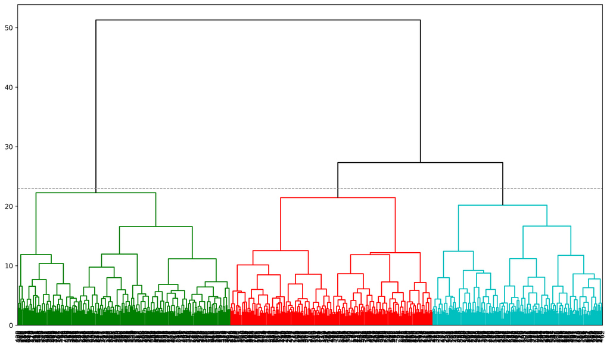

```python
# Select attributes
X = customers_std

# Create a figure
plt.figure(figsize=(16,9), dpi=300)

# Create linkage
Z = sch.linkage(X, method='ward', optimal_ordering=True)

# Draw a dendrogram
sch.dendrogram(Z, leaf_rotation=90, leaf_font_size=10,
               color_threshold=23, above_threshold_color='black')

# Add horizontal line
plt.axhline(y=23, c='grey', lw=1, linestyle='dashed')

# Show the plot
plt.show()
```

#### 5.1.3 Modelling

```python
model = AgglomerativeClustering(n_clusters=3, affinity='euclidean')
clust = model.fit(X)
```

```python
customers_std['clusters'] = clust.labels_
customers['clusters'] = clust.labels_
```

```python
customers.head()
```

| customer_id | Recency | Frequency | MonetaryValue | UniqueProduct | FrequentlyPurchasedProduct | Gender | Age | State | Discount | Season | UniqueSeason | DeliveryTime | clusters |
| --- | --- | --- | --- | --- | --- | --- | --- | --- | --- | --- | --- | --- | --- |
| 1 | 204 | 3 | 1641 | 2 | Jacket | Female | 30.0 | Northern Territory | 14.01000 | Autumn | 2 | 26 | 0 |
| 7 | 157 | 1 | 1017 | 3 | Trousers | Bigender | 76.0 | Queensland | 0.90000 | Autumn | 1 | 2 | 1 |
| 10 | 230 | 1 | 270 | 1 | Trousers | Bigender | 70.0 | Western Australia | 5.26000 | Autumn | 1 | 20 | 2 |
| 11 | 150 | 1 | 382 | 2 | Shirt | Agender | 39.0 | Northern Territory | 10.77500 | Autumn | 1 | 8 | 2 |
| 12 | 128 | 1 | 1551 | 3 | Jacket | Bigender | 78.0 | South Australia | 7.84125 | Winter | 1 | 12 | 1 |

#### 5.1.4 Interpret The Segment

```python
customers.groupby(['clusters'])['Recency','Frequency','MonetaryValue'].agg(['mean','count']).T
```

|  | clusters | 0 | 1 | 2 |
| --- | --- | --- | --- | --- |
| Recency | mean | 81.647321 | 146.877934 | 147.949721 |
|  | count | 224.000000 | 213.000000 | 179.000000 |
| Frequency | mean | 2.500000 | 1.150235 | 1.050279 |
|  | count | 224.000000 | 213.000000 | 179.000000 |
| MonetaryValue | mean | 2648.955357 | 1386.840376 | 799.089385 |
|  | count | 224.000000 | 213.000000 | 179.000000 |

```python
customers.groupby(['clusters','FrequentlyPurchasedProduct'])['clusters'].agg(['count'])
```

| clusters | FrequentlyPurchasedProduct | count |
| --- | --- | --- |
| 0 | Jacket | 88 |
|  | Shirt | 62 |
|  | Trousers | 74 |
| 1 | Jacket | 65 |
|  | Shirt | 70 |
|  | Trousers | 78 |
| 2 | Jacket | 67 |
|  | Shirt | 53 |
|  | Trousers | 59 |

```python
customers.groupby(['clusters','Season'])['clusters'].agg(['count'])
```

| clusters | Season | count |
| --- | --- | --- |
| 0 | Autumn | 66 |
|  | Spring | 41 |
|  | Summer | 47 |
|  | Winter | 70 |
| 1 | Autumn | 68 |
|  | Spring | 38 |
|  | Summer | 38 |
|  | Winter | 69 |
| 2 | Autumn | 57 |
|  | Spring | 28 |
|  | Summer | 35 |
|  | Winter | 59 |

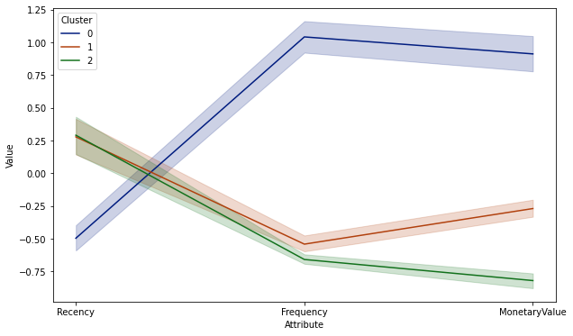

```python
# Create the dataframe
df_normalized = customers_std[['Recency', 'Frequency', 'MonetaryValue']]
df_normalized['ID'] = customers.index
df_normalized['Cluster'] = clust.labels_

# Melt The Data
df_nor_melt = pd.melt(df_normalized.reset_index(),
                      id_vars=['ID', 'Cluster'],
                      value_vars=['Recency','Frequency','MonetaryValue'],
                      var_name='Attribute',
                      value_name='Value')
df_nor_melt.head()

# Visualize it
plt.figure(figsize=(10,6))
sns.lineplot('Attribute', 'Value', hue='Cluster', palette='dark', data=df_nor_melt)
plt.show()
```

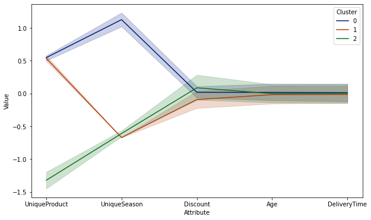

```python
# Create the dataframe
df_normalized = customers_std[['UniqueProduct', 'UniqueSeason', 'Discount', 'Age', 'DeliveryTime']]
df_normalized['ID'] = customers.index
df_normalized['Cluster'] = clust.labels_

# Melt The Data
df_nor_melt = pd.melt(df_normalized.reset_index(),
                      id_vars=['ID', 'Cluster'],
                      value_vars=['UniqueProduct', 'UniqueSeason', 'Discount', 'Age', 'DeliveryTime'],
                      var_name='Attribute',
                      value_name='Value')
df_nor_melt.head()

# Visualize it
plt.figure(figsize=(10,6))
sns.lineplot('Attribute', 'Value', hue='Cluster', palette='dark', data=df_nor_melt)
plt.show()
```

- cluster 0: *loyal customer*
  - buy the product recently
  - most frequent
  - spend more
  - varied products
  - does not depend on season
  - frequently purchased product is jacket
  - most deals are in winter
- cluster 1: *need-based customer*
  - buy the product at the old time
  - less frequent
  - moderate to spend
  - varied products
  - season is likely to affect
  - frequently purchased product is trousers
  - most deals are in winter
- cluster 2: *churned customer*
  - buy the product at the old time
  - least frequent
  - least to spend
  - invariable products
  - season is likely to affect
  - frequently purchased product is jacket
  - most deals are in winter
- *discount, age, delivery time tend to have no effect.*

## 6. Answers to Business Problems and Business Recommendation

### 1. Sales experienced a significant increase in the early Autumn and Winter seasons, then decreased significantly in the following month.

- Is there a correlation between the number of product sales and the season?
- Is there certain product that affects sales in certain seasons?
- How to reduce the decline in product sales (up to 25.32%) in all seasons?

```python
df_ml_pred_nov.columns = df_ml.columns
df_ml_pred_nov_dec = df_ml_pred_nov.loc[10:11]
df_sales_all = pd.concat([df_ml,df_ml_pred_nov_dec], ignore_index=True)
df_sales_all['season'] =df_sales_all['month'].apply(lambda x: season_dict[x])
df_begin = df_sales_all[df_sales_all['month'].isin([3,4,6,7])]
df_end = df_sales_all[~(df_sales_all['month'].isin([3,4,6,7]))]
ftest = stats.f_oneway(df_begin['total_sales'], df_end['total_sales'])

# p-value
p_value = ftest.pvalue
alpha = 0.05
print('P-Value :',p_value)

if p_value >= alpha:
    print('There is no sufficient evidence to conclude that there is a significant correlation between changing seasons and total sales')
else:
    print('There is sufficient evidence to conclude that there is a significant correlation between changing seasons and total sales')
```

```
P-Value : 0.0062801181454922046
There is sufficient evidence to conclude that there is a significant correlation between changing seasons and total sales
```

*trousers*

```python
df_ml_trousers_pred_nov.columns = df_ml_trousers.columns
df_ml_trousers_pred_nov_dec = df_ml_trousers_pred_nov.loc[10:11]
df_sales_trousers_all = pd.concat([df_ml_trousers,df_ml_trousers_pred_nov_dec], ignore_index=True)
df_sales_trousers_all['season'] =df_sales_trousers_all['month'].apply(lambda x: season_dict[x])
df_begin = df_sales_trousers_all[df_sales_trousers_all['month'].isin([3,4,6,7])]
df_end = df_sales_trousers_all[~(df_sales_trousers_all['month'].isin([3,4,6,7]))]
ftest = stats.f_oneway(df_begin['trousers'], df_end['trousers'])

# p-value
p_value = ftest.pvalue
alpha = 0.05
print('P-Value :',p_value)

if p_value >= alpha:
    print('There is no sufficient evidence to conclude that there is a significant correlation between changing seasons and total sales of trousers')
else:
    print('There is sufficient evidence to conclude that there is a significant correlation between changing seasons and total sales of trousers')
```

```
P-Value : 0.03470099011780684
There is sufficient evidence to conclude that there is a significant correlation between changing seasons and total sales of trousers
```

*jacket*

```python
df_ml_jacket_pred_nov.columns = df_ml_jacket.columns
df_ml_jacket_pred_nov_dec = df_ml_jacket_pred_nov.loc[10:11]
df_sales_jacket_all = pd.concat([df_ml_jacket,df_ml_jacket_pred_nov_dec], ignore_index=True)
df_sales_jacket_all['season'] =df_sales_jacket_all['month'].apply(lambda x: season_dict[x])
df_begin = df_sales_jacket_all[df_sales_jacket_all['month'].isin([3,4,6,7])]
df_end = df_sales_jacket_all[~(df_sales_jacket_all['month'].isin([3,4,6,7]))]
ftest = stats.f_oneway(df_begin['jacket'], df_end['jacket'])

# p-value
p_value = ftest.pvalue
alpha = 0.05
print('P-Value :',p_value)

if p_value >= alpha:
    print('There is no sufficient evidence to conclude that there is a significant correlation between changing seasons and total sales of jacket')
else:
    print('There is sufficient evidence to conclude that there is a significant correlation between changing seasons and total sales of jacket')
```

```
P-Value : 0.042896304078451686
There is sufficient evidence to conclude that there is a significant correlation between changing seasons and total sales of jacket
```

*shirt*

```python
df_ml_shirt_pred_nov.columns = df_ml_shirt.columns
df_ml_shirt_pred_nov_dec = df_ml_shirt_pred_nov.loc[10:11]
df_sales_shirt_all = pd.concat([df_ml_shirt,df_ml_shirt_pred_nov_dec], ignore_index=True)
df_sales_shirt_all['season'] =df_sales_shirt_all['month'].apply(lambda x: season_dict[x])
df_begin = df_sales_shirt_all[df_sales_shirt_all['month'].isin([3,4,6,7])]
df_end = df_sales_shirt_all[~(df_sales_shirt_all['month'].isin([3,4,6,7]))]
ftest = stats.f_oneway(df_begin['shirt'], df_end['shirt'])

# p-value
p_value = ftest.pvalue
alpha = 0.05
print('P-Value :',p_value)

if p_value >= alpha:
    print('There is no sufficient evidence to conclude that there is a significant correlation between changing seasons and total sales of shirt')
else:
    print('There is sufficient evidence to conclude that there is a significant correlation between changing seasons and total sales of shirt')
```

```
P-Value : 0.0045763512857082194
There is sufficient evidence to conclude that there is a significant correlation between changing seasons and total sales of shirt
```

### 2. Overall sales in 2021 did not experience significant movement.

- How to increase product sales if it is proven that there is a decline in sales in 2021?
- What factors affect the decline in sales?

```python
# pearson
(r,p_value) = stats.pearsonr(df_sales_all['month'], df_sales_all['total_sales'])
print('r:',r)
print('p-value:',p_value)

#if p-value < 0.05
#There is sufficient evidence to conclude that there is a significant linear relationship between x and y
#Because the correlation coefficient is significantly different from zero
```

```
r: -0.4410483704740323
p-value: 0.15122801787806897
```

*trousers*

```python
# pearson
(r,p_value) = stats.pearsonr(df_sales_trousers_all['month'], df_sales_trousers_all['trousers'])
print('r:',r)
print('p-value:',p_value)
```

```
r: -0.3845486761386107
p-value: 0.2171067697798996
```

*jacket*

```python
# pearson
(r,p_value) = stats.pearsonr(df_sales_jacket_all['month'], df_sales_jacket_all['jacket'])
print('r:',r)
print('p-value:',p_value)
```

```
r: -0.4094906150900982
p-value: 0.1861990751595597
```

*shirt*

```python
# pearson
(r,p_value) = stats.pearsonr(df_sales_shirt_all['month'], df_sales_shirt_all['shirt'])
print('r:',r)
print('p-value:',p_value)
```

```
r: -0.1735715226094911
p-value: 0.5895510485305188
```

- *The correlation of sales of all products every month has decreased, as can be seen from the negative r value. However, the p-value > 0.05 indicates that although there was a decrease in sales, the decline was not significant or sales in 2021 were stagnant*

*factors affect the sales trend*

- *Based on the interpretation of customer segmentation 5.1.4 and statistical testing, it is known that the ***season quite affects customer transactions**.

### 3. Conclusion and Business Recommendation

*in presentation slides*

### 4. Export Data

```python
df_sales_all_export = df_sales_all.copy()
df_sales_jacket_export = df_sales_jacket_all.copy()
df_sales_shirt_export = df_sales_shirt_all.copy()
df_sales_trousers_export = df_sales_trousers_all.copy()
```

```python
import calendar
```

```python
df_sales_all_export['month'] = df_sales_all_export['month'].apply(lambda x: calendar.month_abbr[x])
df_sales_trousers_export['month'] = df_sales_trousers_export['month'].apply(lambda x: calendar.month_abbr[x])
df_sales_jacket_export['month'] = df_sales_jacket_export['month'].apply(lambda x: calendar.month_abbr[x])
df_sales_shirt_export['month'] = df_sales_shirt_export['month'].apply(lambda x: calendar.month_abbr[x])
```

```python
from google.colab import files
df_sales_all_export.to_excel ("sales_prediction_all_products.xlsx", index = False, header=True)
files.download('sales_prediction_all_products.xlsx')
```

```python
from google.colab import files
df_sales_trousers_export.to_excel ("sales_prediction_trousers.xlsx", index = False, header=True)
files.download('sales_prediction_trousers.xlsx')
```

```python
from google.colab import files
df_sales_jacket_export.to_excel ("sales_prediction_jacket.xlsx", index = False, header=True)
files.download('sales_prediction_jacket.xlsx')
```

```python
from google.colab import files
df_sales_shirt_export.to_excel ("sales_prediction_shirt.xlsx", index = False, header=True)
files.download('sales_prediction_shirt.xlsx')
```